# Building Multi-Agent AI System Using LangGraph and LangSmith

## Part 4: Adding Long-Term Memory (User Preferences)

We have successfully built an agent workflow that handles verification and multi-agent execution. Let's enhance it further by integrating **long-term memory**. While short-term memory (via checkpointers) maintains context within a single conversation, long-term memory allows our agent to store and recall information *between conversations* or across different sessions for the same user. This is crucial for personalization.

[figure not shown]

In this step, we will add two new nodes to manage user preferences related to music:

- **`load_memory` node**: This node will load any existing music preferences associated with the verified `customer_id` from our `InMemoryStore` (our long-term memory store) into the current graph `State` (`loaded_memory`). This ensures the agent has relevant context for personalized responses.
- **`create_memory` node**: After the main query is handled, this node will analyze the conversation that just took place. If the customer shared any new music interests, it will update or create a `UserProfile` in the `InMemoryStore`, saving these preferences for future interactions.

```python
from langgraph.store.base import BaseStore # Base class for defining custom stores for LangGraph

# Helper function to format user memory (music preferences) into a readable string.
def format_user_memory(user_data):
    """Formats music preferences from users, if available."""
    profile = user_data['memory'] # Access the 'memory' key from the stored dictionary
    result = "" # Initialize an empty string for the formatted result

    # Check if the profile object has a 'music_preferences' attribute and if it's not empty.
    if hasattr(profile, 'music_preferences') and profile.music_preferences:
        # If preferences exist, join them into a comma-separated string.
        result += f"Music Preferences: {', '.join(profile.music_preferences)}"

    return result.strip() # Return the formatted string, removing any leading/trailing whitespace.

# Define the `load_memory` node function.
# This node loads a user's long-term memory (music preferences) into the current state.
def load_memory(state: State, config: RunnableConfig, store: BaseStore):
    """Loads music preferences from users, if available."""

    user_id = state["customer_id"] # Get the current customer ID from the state.
    namespace = ("memory_profile", user_id) # Define a namespace for storing user-specific memory.
                                          # This creates a unique key for each user's profile.

    # Attempt to retrieve existing memory for this user from the `InMemoryStore`.
    existing_memory = store.get(namespace, "user_memory")

    formatted_memory = "" # Initialize formatted memory as empty.

    # If memory exists and has a value, format it using our helper function.
    if existing_memory and existing_memory.value:
        formatted_memory = format_user_memory(existing_memory.value)

    # Update the `loaded_memory` field in the state with the retrieved and formatted memory.
    return {"loaded_memory" : formatted_memory}
```

```python
# Define a Pydantic BaseModel to structure the `UserProfile` for long-term memory.
# This ensures that user preferences are stored in a consistent and verifiable format.
class UserProfile(BaseModel):
    # `customer_id`: Required field for the customer's unique identifier.
    customer_id: str = Field(
        description="The customer ID of the customer"
    )
    # `music_preferences`: A list of strings to store the customer's music interests.
    music_preferences: List[str] = Field(
        description="The music preferences of the customer"
    )
```

```python
# Define the system prompt for the `create_memory` LLM.
# This prompt instructs an LLM to act as an analyst, analyzing conversation history
# to extract and update user music preferences in a structured `UserProfile` format.
create_memory_prompt = """You are an expert analyst that is observing a conversation that has taken place between a customer and a customer support assistant. The customer support assistant works for a digital music store, and has utilized a multi-agent team to answer the customer's request.
You are tasked with analyzing the conversation that has taken place between the customer and the customer support assistant, and updating the memory profile associated with the customer. The memory profile may be empty. If it's empty, you should create a new memory profile for the customer.

You specifically care about saving any music interest the customer has shared about themselves, particularly their music preferences to their memory profile.

To help you with this task, I have attached the conversation that has taken place between the customer and the customer support assistant below, as well as the existing memory profile associated with the customer that you should either update or create.

The customer's memory profile should have the following fields:
- customer_id: the customer ID of the customer
- music_preferences: the music preferences of the customer

These are the fields you should keep track of and update in the memory profile. If there has been no new information shared by the customer, you should not update the memory profile. It is completely okay if you do not have new information to update the memory profile with. In that case, just leave the values as they are.

*IMPORTANT INFORMATION BELOW*

The conversation between the customer and the customer support assistant that you should analyze is as follows:
{conversation}

The existing memory profile associated with the customer that you should either update or create based on the conversation is as follows:
{memory_profile}

Ensure your response is an object that has the following fields:
- customer_id: the customer ID of the customer
- music_preferences: the music preferences of the customer

For each key in the object, if there is no new information, do not update the value, just keep the value that is already there. If there is new information, update the value.

Take a deep breath and think carefully before responding.
"""

# Define the `create_memory` node function.
# This node is responsible for analyzing the conversation and saving/updating user music preferences.
def create_memory(state: State, config: RunnableConfig, store: BaseStore):
    user_id = str(state["customer_id"]) # Get the customer ID from the current state (convert to string).
    namespace = ("memory_profile", user_id) # Define the namespace for this user's memory profile.

    # Retrieve the existing memory profile for this user from the long-term store.
    existing_memory = store.get(namespace, "user_memory")

    formatted_memory = "" # Initialize formatted memory for the prompt.
    if existing_memory and existing_memory.value:
        existing_memory_dict = existing_memory.value # Get the dictionary containing the UserProfile instance.
        # Format existing music preferences into a string for the prompt.
        formatted_memory = (
            f"Music Preferences: {', '.join(existing_memory_dict.get('memory').music_preferences or [])}" # Access the UserProfile object via 'memory' key
        )

    # Create a SystemMessage with the formatted prompt, injecting the full conversation history
# and the existing memory profile.
    formatted_system_message = SystemMessage(content=create_memory_prompt.format(conversation=state["messages"], memory_profile=formatted_memory))

    # Invoke the LLM with structured output (`UserProfile`) to analyze the conversation
    # and update the memory profile based on new information.
    updated_memory = llm.with_structured_output(UserProfile).invoke([formatted_system_message])

    key = "user_memory" # Define the key for storing this specific memory object.

    # Store the updated memory profile back into the `InMemoryStore`.
    # We wrap `updated_memory` in a dictionary under the key 'memory' for consistency in access.
    store.put(namespace, key, {"memory": updated_memory})
```

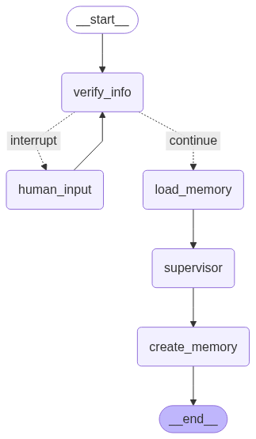

```python
# Initialize the final StateGraph for our complete multi-agent system, including memory management.
multi_agent_final = StateGraph(State)

# Add all necessary nodes to the graph.
multi_agent_final.add_node("verify_info", verify_info)         # Node for customer verification
multi_agent_final.add_node("human_input", human_input)         # Node for human-in-the-loop interruption
multi_agent_final.add_node("load_memory", load_memory)         # Node for loading user long-term memory
multi_agent_final.add_node("supervisor", supervisor_prebuilt) # Supervisor for routing to sub-agents
multi_agent_final.add_node("create_memory", create_memory)     # Node for saving/updating user long-term memory

# Define the initial entry point: all interactions start with verification.
multi_agent_final.add_edge(START, "verify_info")

# Define the conditional routing after `verify_info`.
# If verification is successful, proceed to load memory. Otherwise, prompt for human input.
multi_agent_final.add_conditional_edges(
    "verify_info",
    should_interrupt,
    {
        "continue": "load_memory", # If verified, load user memory
        "interrupt": "human_input", # If not verified, request human input
    },
)

# After `human_input` (resume), loop back to `verify_info` to re-attempt verification.
multi_agent_final.add_edge("human_input", "verify_info")

# After loading memory, proceed to the supervisor for main query processing.
multi_agent_final.add_edge("load_memory", "supervisor")

# After the supervisor completes, save/update the user's memory.
multi_agent_final.add_edge("supervisor", "create_memory")

# The graph ends after memory has been updated.
multi_agent_final.add_edge("create_memory", END)

# Compile the entire, sophisticated graph.
multi_agent_final_graph = multi_agent_final.compile(name="multi_agent_verify", checkpointer=checkpointer, store=in_memory_store)

# Display the visualization of the complete graph.
show_graph(multi_agent_final_graph)
```

Let's test it out! We'll use a complex query that requires verification, then touches both music and invoice information, and also includes a music preference that should be saved to long-term memory.

```python
thread_id = uuid.uuid4() # Generate a fresh unique thread ID for this demonstration.

# A comprehensive question that includes customer ID, invoice query, and music preference.
question = "My phone number is +55 (12) 3923-5555. How much was my most recent purchase? What albums do you have by the Rolling Stones?"

# Configuration for the graph invocation.
# Note: The user_id is passed as a configurable parameter, although in this specific example,
# the customer_id is extracted dynamically by the verify_info node.
# For real-world use, ensure consistent handling of user identifiers.
config = {"configurable": {"thread_id": thread_id, "user_id" : "1"}}

# Invoke the final multi-agent graph.
# This will run through verification, memory loading, supervisor routing (to invoice then music),
# and finally memory saving.
result = multi_agent_final_graph.invoke({"messages": [HumanMessage(content=question)]}, config=config)

# Print all messages in the final state to observe the complete interaction flow.
for message in result["messages"]:
    message.pretty_print()
```

```
================================ Human Message =================================

My phone number is +55 (12) 3923-5555. How much was my most recent purchase? What albums do you have by the Rolling Stones?
================================ System Message ================================

Thank you for providing your information! I was able to verify your account with customer id 1.
================================== Ai Message ==================================
Name: supervisor
Tool Calls:
  transfer_to_invoice_information_subagent (chatcmpl-tool-9b50c99783f249a69c528235f7827c68)
 Call ID: chatcmpl-tool-9b50c99783f249a69c528235f7827c68
  Args:
================================= Tool Message =================================
Name: transfer_to_invoice_information_subagent

Successfully transferred to invoice_information_subagent
================================== Ai Message ==================================
Name: invoice_information_subagent

Your most recent purchase was on August 7, 2025, and the total amount was $8.91. I am unable to provide information about albums by the Rolling Stones. Would you like to search for something else?
================================== Ai Message ==================================
Name: invoice_information_subagent

Transferring back to supervisor
Tool Calls:
  transfer_back_to_supervisor (5e815485-36af-4d4e-8135-c49c84aec998)
 Call ID: 5e815485-36af-4d4e-8135-c49c84aec998
  Args:
================================= Tool Message =================================
Name: transfer_back_to_supervisor

Successfully transferred back to supervisor
================================== Ai Message ==================================
Name: supervisor
Tool Calls:
  transfer_to_music_catalog_information_subagent (chatcmpl-tool-00e55d429f4349579d9c504d58a96d69)
 Call ID: chatcmpl-tool-00e55d429f4349579d9c504d58a96d69
  Args:
================================= Tool Message =================================
Name: transfer_to_music_catalog_information_subagent
```

[output cut: 16 more lines]

```
Name: music_catalog_subagent

Transferring back to supervisor
Tool Calls:
  transfer_back_to_supervisor (03f9bce5-c17c-4672-a154-501c962b94c2)
 Call ID: 03f9bce5-c17c-4672-a154-501c962b94c2
  Args:
================================= Tool Message =================================
Name: transfer_back_to_supervisor

Successfully transferred back to supervisor
================================== Ai Message ==================================
Name: supervisor

Is there anything else I can help you with?
```

Let's take a look at the memory! We expect the music preferences (e.g., 'Rolling Stones') to be saved in our `in_memory_store` under the customer ID associated with the phone number `+55 (12) 3923-5555` (which maps to customer ID 1 in our Chinook DB).

```python
user_id = "1" # The customer ID we expect to be associated with the phone number used.
namespace = ("memory_profile", user_id) # The namespace used to store this user's memory.

# Retrieve the user's memory profile from the `in_memory_store`.
# `.value` retrieves the actual data stored, which should be a dictionary containing the UserProfile instance.
memory_data = in_memory_store.get(namespace, "user_memory")

# Check if memory_data exists and has a 'memory' key (which holds the UserProfile object).
if memory_data and "memory" in memory_data.value:
    saved_music_preferences = memory_data.value.get("memory").music_preferences
else:
    saved_music_preferences = [] # Default to empty list if no preferences found.

print(f"Saved Music Preferences for Customer ID {user_id}: {saved_music_preferences}")
```

```
Saved Music Preferences for Customer ID 1: ['Rolling Stones']
```

## (Optional) Build a Swarm Multi-Agent Graph

Beyond the centralized supervisor pattern, another powerful approach to multi-agent systems is the **Swarm architecture**. While the supervisor relies on a single orchestrating agent, a swarm model emphasizes decentralized collaboration.

### Swarm Architecture

[figure not shown]

In a swarm, multiple specialized agents work together without a central coordinator. Each agent is aware of the others' capabilities and can *directly hand off* a task to the most appropriate peer when its own expertise is insufficient or when a query crosses domains. This creates a flexible, dynamic flow where agents pass control to each other as needed.

At LangChain, we've built a [lightweight library](https://github.com/langchain-ai/langgraph-swarm-py) to help create Swarm agents easily with LangGraph.

### Swarm vs Supervisor

[figure not shown]

Let's recap the key differences:

| Feature | Supervisor Architecture | Swarm Architecture |
| --- | --- | --- |
| **Control Flow** | Centralized; supervisor routes queries. | Decentralized; agents hand off to each other. |
| **Decision-making** | Supervisor decides which agent to call next. | Each agent decides who to hand off to. |
| **Hierarchy** | Clear hierarchy: Supervisor -> Sub-agents. | Flat, collaborative structure. |
| **Modularity** | Add/remove sub-agents by updating supervisor. | Agents need to know about possible handoffs. |
| **Predictability** | More predictable routing. | More dynamic, emergent behavior. |
| **Resilience** | Supervisor is a single point of failure. | More resilient to individual agent failures. |

The choice between a supervisor and a swarm depends on your use case. If you need strict control and a clear workflow, a supervisor is often better. If your problem benefits from dynamic, collaborative problem-solving and greater adaptability, a swarm might be more suitable.

For more information, there's a great video by Lance from our team at LangChain breaking down Supervisor vs. Swarm: [Multi-agent swarms with LangGraph](https://www.youtube.com/watch?v=JeyDrn1dSUQ)

Let's create swarm agents!

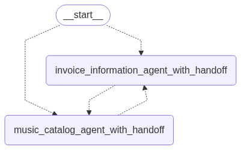

```python
from langgraph_swarm import create_handoff_tool, create_swarm # Import utilities for creating swarm agents and handoff tools

# Create our handoff tools between agents.
# These are special tools that, when called by an agent, signal a transfer of control
# to another named agent within the swarm.

transfer_to_invoice_agent_handoff_tool = create_handoff_tool(
    agent_name = "invoice_information_agent_with_handoff", # The name of the target agent for this handoff
    description = "Transfer user to the invoice information agent that can help with invoice information" # Description for LLM
)

transfer_to_music_catalog_agent_handoff_tool = create_handoff_tool(
    agent_name = "music_catalog_agent_with_handoff",
    description = "Transfer user to the music catalog agent that can help with music searches and music catalog information"
)

# Recreate our agents, but this time, add the handoff tools to their available tools.
# This allows each agent to `request` a handoff to the other when appropriate.

# First, combine the handoff tools with the existing specific tools for each agent.
invoice_tools_with_handoff = [transfer_to_music_catalog_agent_handoff_tool] + invoice_tools
music_tools_with_handoff = [transfer_to_invoice_agent_handoff_tool] + music_tools

# Recreate the invoice information agent with its original prompt and its new set of tools (including handoff).
invoice_information_agent_with_handoff = create_react_agent(
    llm,
    invoice_tools_with_handoff,
    prompt = invoice_subagent_prompt,
    name = "invoice_information_agent_with_handoff" # Give it a specific name for the swarm
)

# Recreate the music catalog agent with its original prompt and its new set of tools (including handoff).
# Note: The music catalog agent prompt is generated dynamically, as defined earlier.
music_catalog_agent_with_handoff = create_react_agent(
    llm,
    music_tools_with_handoff,
    prompt = generate_music_assistant_prompt(),
    name = "music_catalog_agent_with_handoff" # Give it a specific name for the swarm
)


# Create the swarm workflow. `create_swarm` handles the orchestration logic
# for agents to hand off to each other without a central supervisor.
swarm_workflow = create_swarm(
    agents = [invoice_information_agent_with_handoff, music_catalog_agent_with_handoff], # The agents participating in the swarm
    default_active_agent = "invoice_information_agent_with_handoff", # The agent that will be active first by default
)

# Compile the swarm graph. This makes it runnable and integrates memory.
swarm_agents = swarm_workflow.compile(
    checkpointer = checkpointer,
    store = in_memory_store
)

# Display the graph of the swarm. Notice it's different from the supervisor graph,
# showing connections for potential handoffs rather than a central hub.
show_graph(swarm_agents)
```

Now let's test it out! We'll give it a music-related question, but because the `default_active_agent` is set to the invoice agent, it should *hand off* to the music catalog agent.

```python
# Create a new thread for this swarm test.
thread_id = uuid.uuid4()

# Ask a music-related question.
question = "Do you have any albums by the Rolling Stones?"

# Configure the invocation with the thread ID.
config = {"configurable": {"thread_id": thread_id}}

# Invoke the swarm agents. Even though the default active agent is `invoice_information_agent_with_handoff`,
# it should recognize that the query is for music and hand off to `music_catalog_agent_with_handoff`.
result = swarm_agents.invoke({"messages": [HumanMessage(content=question)]}, config=config)

# Print the messages to observe the handoff and the final response.
for message in result["messages"]:
    message.pretty_print()
```

```
================================ Human Message =================================

Do you have any albums by the Rolling Stones?
================================== Ai Message ==================================
Name: invoice_information_agent_with_handoff
Tool Calls:
  transfer_to_music_catalog_agent_with_handoff (chatcmpl-tool-0872f50781fd41efa13930f99be577cf)
 Call ID: chatcmpl-tool-0872f50781fd41efa13930f99be577cf
  Args:
================================= Tool Message =================================
Name: transfer_to_music_catalog_agent_with_handoff

Successfully transferred to music_catalog_agent_with_handoff
================================== Ai Message ==================================
Name: music_catalog_agent_with_handoff
Tool Calls:
  get_albums_by_artist (chatcmpl-tool-f1d12df4e6fc44a79ab7fe723a8a3081)
 Call ID: chatcmpl-tool-f1d12df4e6fc44a79ab7fe723a8a3081
  Args:
    artist: Rolling Stones
================================= Tool Message =================================
Name: get_albums_by_artist

[{'Title': 'Hot Rocks, 1964-1971 (Disc 1)', 'Name': 'The Rolling Stones'}, {'Title': 'No Security', 'Name': 'The Rolling Stones'}, {'Title': 'Voodoo Lounge', 'Name': 'The Rolling Stones'}]
================================== Ai Message ==================================
Name: music_catalog_agent_with_handoff

The Rolling Stones have several albums available, including "Hot Rocks, 1964-1971 (Disc 1)", "No Security", and "Voodoo Lounge".
```

## Evaluations

**Evaluations** are a quantitative and systematic way to measure the performance of your LLM applications, especially agents. They are critical because LLMs don't always behave predictably—even small changes in prompts, models, or inputs can significantly impact results. Evaluations provide a structured method to:

1. **Identify Failures**: Pinpoint where and why your agent is not performing as expected.
2. **Compare Versions**: Quantitatively compare different versions of your application (e.g., after prompt changes, model updates, or architectural shifts).
3. **Build Reliability**: Iteratively improve your agent's quality and ensure it meets desired performance benchmarks.

An evaluation typically comprises three core components:

1. **A Dataset**: A collection of test inputs and their corresponding expected outputs (ground truth). This serves as the benchmark against which your application's performance is measured.
2. **An Application or Target Function**: The specific piece of your LLM application (e.g., an agent, a chain, or a node) that you want to evaluate. This function takes an input and returns an output.
3. **Evaluators**: Metrics or models (often LLMs themselves, known as "LLM-as-a-judge") that score your target function's outputs against the dataset's ground truth or specific criteria.

[figure not shown]

There are many ways to evaluate an agent, depending on what aspect of its performance you want to measure. Today, we will cover three common types of agent evaluations:

1. **Final Response Evaluation**: Assess the quality of the agent's ultimate answer to a user query, treating the agent as a black box.
2. **Single Step Evaluation**: Focus on the performance of a specific, critical step within the agent's execution (e.g., whether it correctly selects a tool).
3. **Trajectory Evaluation**: Analyze the entire sequence of steps (the "trajectory") an agent takes, assessing whether it follows the expected path of tool calls and internal reasoning.

### Evaluating The Final Response

Evaluating the final response is the most common and often the simplest way to assess an agent's overall effectiveness. It involves treating the agent as a "black box" and focusing solely on whether the final output successfully addresses the user's intent, regardless of the intermediate steps taken.

- **Input**: The original user query.
- **Output**: The agent's final, human-facing response.

[figure not shown]

#### 1. Create a Dataset for Final Response Evaluation

We'll use LangSmith to create and manage our evaluation datasets. A dataset consists of `inputs` (the user questions) and `outputs` (the expected correct responses). This ground truth allows evaluators to compare the agent's generated response against what is considered correct.

```python
from langsmith import Client # Import the LangSmith Client for dataset and experiment management

client = Client() # Initialize the LangSmith client. This will connect to your LangSmith account.

# Define a list of example inputs and expected outputs for our dataset.
# Each dictionary represents a test case with a 'question' (input) and a 'response' (ground truth output).
examples = [
    {
        "question": "My name is Aaron Mitchell. My number associated with my account is +1 (204) 452-6452. I am trying to find the invoice number for my most recent song purchase. Could you help me with it?",
        "response": "The Invoice ID of your most recent purchase was 342.",
    },
    {
        "question": "I'd like a refund.",
        "response": "I need additional information to help you with the refund. Could you please provide your customer identifier so that we can fetch your purchase history?",
    },
    {
        "question": "Who recorded Wish You Were Here again?",
        "response": "Wish You Were Here is an album by Pink Floyd",
    },
    {
        "question": "What albums do you have by Coldplay?",
        "response": "There are no Coldplay albums available in our catalog at the moment.",
    },
]

dataset_name = "LangGraph 101 Multi-Agent: Final Response" # Define a name for our dataset.

# Check if the dataset already exists in LangSmith to avoid recreation.
if not client.has_dataset(dataset_name=dataset_name):
    # If not, create the dataset.
    dataset = client.create_dataset(dataset_name=dataset_name)
    # Populate the dataset with our examples.
    # `inputs` are extracted from the 'question' key, `outputs` from the 'response' key.
    client.create_examples(
        inputs=[{"question": ex["question"]} for ex in examples],
        outputs=[{"response": ex["response"]} for ex in examples],
        dataset_id=dataset.id # Associate examples with the created dataset.
    )
```

#### 2. Define Application Logic to be Evaluated

We need a function that encapsulates the execution of our LangGraph and returns the final response in a format suitable for evaluation. Since our graph includes a `human_input` interrupt for customer verification, we must handle this in our evaluation function. We'll simulate the user providing their customer ID (e.g., "My customer ID is 10") to allow the graph to proceed past the verification step.

```python
import uuid # For generating unique thread IDs
from langgraph.types import Command # For resuming graph execution after an interrupt

graph = multi_agent_final_graph # Reference our complete, final multi-agent graph

async def run_graph(inputs: dict):
    """Run graph and track the final response for evaluation."""
    # Creating a unique thread ID for each evaluation run to ensure isolation.
    thread_id = uuid.uuid4()
    # Configuration for the graph invocation. User ID '10' is used here for a specific test scenario.
    configuration = {"configurable": {"thread_id": thread_id, "user_id" : "10"}}

    # Invoke the graph with the initial user question.
    # This invocation will likely hit the `human_input` node and interrupt if `customer_id` is not present.
    result = await graph.ainvoke({"messages": [
        { "role": "user", "content": inputs['question']}]}, config = configuration)

    # After the first invocation, if an interrupt occurred, resume it.
    # We explicitly provide a (simulated) customer ID to pass the verification step.
    # The `thread_id` in the config must match the initial invocation to resume the correct state.
    result = await graph.ainvoke(Command(resume="My customer ID is 10"), config={"configurable": {"thread_id": thread_id, "user_id" : "10"}})

    # Return the content of the last message in the conversation as the final response.
    # This is the output that will be evaluated against the dataset's `response`.
    return {"response": result['messages'][-1].content}
```

#### 3. Define the Evaluator for Final Response

Evaluators are functions that take the application's output, the original input, and sometimes the reference output, and return a score or feedback. We can use pre-built evaluators or define our own.

##### Using a Pre-built Evaluator (OpenEvals)

LangSmith integrates with `openevals`, a library providing ready-to-use LLM-as-a-judge evaluators. The `create_llm_as_judge` function sets up an evaluator that uses an LLM to score responses based on a given prompt (e.g., `CORRECTNESS_PROMPT`).

##### Defining a Custom Evaluator (LLM-as-a-Judge)

For more specific or nuanced evaluation criteria, you can define your own LLM-as-a-judge evaluator. This involves:

1. **Custom Instructions**: A detailed prompt for the LLM that explains its role as a grader and the criteria for scoring.
2. **Structured Output Schema**: A Pydantic `BaseModel` or `TypedDict` to enforce the format of the LLM's grading output (e.g., `is_correct: bool`, `reasoning: str`).
3. **Evaluator Function**: A Python function that calls the structured LLM with the prompt, inputs, and reference outputs, then extracts the relevant score.

This approach gives you maximum flexibility over how your agent's responses are judged.

```python
from openevals.llm import create_llm_as_judge # Import the utility to create LLM-as-judge evaluators
from openevals.prompts import CORRECTNESS_PROMPT # Import a pre-defined prompt for correctness evaluation

# Create an LLM-as-judge evaluator for correctness using the pre-built `CORRECTNESS_PROMPT`.
# `feedback_key="correctness"` sets the name of the score reported in LangSmith.
# `judge=model` specifies which LLM to use for judging.
correctness_evaluator = create_llm_as_judge(
    prompt=CORRECTNESS_PROMPT,
    feedback_key="correctness",
    judge=llm,
)

# Print the content of the pre-defined correctness prompt to understand its instructions.
print(CORRECTNESS_PROMPT)
```

```
You are an expert data labeler evaluating model outputs for correctness. Your task is to assign a score based on the following rubric:

<Rubric>
  A correct answer:
  - Provides accurate and complete information
  - Contains no factual errors
  - Addresses all parts of the question
  - Is logically consistent
  - Uses precise and accurate terminology

  When scoring, you should penalize:
  - Factual errors or inaccuracies
  - Incomplete or partial answers
  - Misleading or ambiguous statements
  - Incorrect terminology
  - Logical inconsistencies
  - Missing key information
</Rubric>

<Instructions>
  - Carefully read the input and output
  - Check for factual accuracy and completeness
  - Focus on correctness of information rather than style or verbosity
</Instructions>

<Reminder>
  The goal is to evaluate factual correctness and completeness of the response.
</Reminder>

<input>
{inputs}
</input>

<output>
{outputs}
</output>

Use the reference outputs below to help you evaluate the correctness of the response:

<reference_outputs>
{reference_outputs}
</reference_outputs>
```

```python
# Custom definition of LLM-as-judge instructions.
    # This prompt provides specific guidelines for the LLM acting as a grader, focusing on factual accuracy.
grader_instructions = """You are a teacher grading a quiz.

You will be given a QUESTION, the GROUND TRUTH (correct) RESPONSE, and the STUDENT RESPONSE.

Here is the grade criteria to follow:
(1) Grade the student responses based ONLY on their factual accuracy relative to the ground truth answer.
(2) Ensure that the student response does not contain any conflicting statements.
(3) It is OK if the student response contains more information than the ground truth response, as long as it is factually accurate relative to the ground truth response.

Correctness:
True means that the student's response meets all of the criteria.
False means that the student's response does not meet all of the criteria.

Explain your reasoning in a step-by-step manner to ensure your reasoning and conclusion are correct."""

# Define the schema for the LLM-as-judge's output using TypedDict.
# This ensures the grading output is structured with a reasoning and a boolean correctness score.
class Grade(TypedDict):
    """Compare the expected and actual answers and grade the actual answer."""
    reasoning: Annotated[str, ..., "Explain your reasoning for whether the actual response is correct or not."]
    is_correct: Annotated[bool, ..., "True if the student response is mostly or exactly correct, otherwise False."]

# Configure the judge LLM to output structured data according to the `Grade` schema.
# `method="json_schema"` ensures JSON-based structured output, `strict=True` enforces strict adherence.
grader_llm = llm.with_structured_output(Grade, method="json_schema", strict=True)

# Define the custom evaluator function `final_answer_correct`.
# This function takes inputs, outputs (from our `run_graph`), and reference outputs (from the dataset).
async def final_answer_correct(inputs: dict, outputs: dict, reference_outputs: dict) -> bool:
    """Evaluate if the final response is equivalent to reference response."""
    # Construct the user prompt for the grader LLM, combining the question, ground truth, and student response.
    user = f"""QUESTION: {inputs['question']}
    GROUND TRUTH RESPONSE: {reference_outputs['response']}
    STUDENT RESPONSE: {outputs['response']}"""

    # Invoke the structured grader LLM with the system instructions and the user prompt.
    # Awaiting the async call as LLM invocations are typically async.
    grade = await grader_llm.ainvoke([{"role": "system", "content": grader_instructions}, {"role": "user", "content": user}])

    # Return the `is_correct` boolean from the grader's output as the evaluation score.
    return grade["is_correct"]
```

#### 4. Run the Final Response Evaluation

Now we're ready to run our evaluation job using the LangSmith client. The `aevaluate` method orchestrates the entire process:

1. It fetches inputs from the specified `data` (our dataset).
2. For each input, it calls our `run_graph` function.
3. It then passes the `run_graph`'s output, along with the original input and dataset's reference output, to each defined `evaluator`.
4. All results are logged and visible in your LangSmith project, providing a comprehensive report of your agent's performance.

Key parameters:

- `run_graph`: Our target function to be evaluated.
- `data`: The name of the dataset created in LangSmith.
- `evaluators`: A list of evaluator functions to apply.
- `experiment_prefix`: A prefix for the experiment name in LangSmith, useful for organizing runs.
- `num_repetitions`: How many times to run each example. (For more robust results, typically >1)
- `max_concurrency`: The maximum number of parallel runs (useful for speeding up evaluation).

Upon completion, you can navigate to your LangSmith project to view detailed traces and aggregated scores.

```python
# Run the evaluation job asynchronously using the LangSmith client.
    # This will execute `run_graph` for each example in the dataset and apply the specified evaluators.
experiment_results = await client.aevaluate(
    run_graph,                        # The asynchronous function that runs our graph and returns its output
    data=dataset_name,                # The name of the LangSmith dataset to use for inputs and references
    evaluators=[final_answer_correct, correctness_evaluator], # List of evaluator functions to apply
    experiment_prefix="agent-Llama-e2e", # A prefix for the experiment name in LangSmith for better organization
    num_repetitions=1,                # Number of times to run each example (1 for quick testing)
    max_concurrency=5,                # Maximum concurrent runs to optimize evaluation speed
)
```

```
View the evaluation results for experiment: 'agent-Llama-e2e-4f89ef54' at:
https://smith.langchain.com/o/ed92af16-6cad-4938-963c-e645d2ca645c/datasets/3dea3bcb-9c19-475a-8d22-a99de27382c1/compare?selectedSessions=5d301a6c-feaf-4fba-8dba-c23bebc27c5d
```

[output not shown]

[output cut: 70 more lines]

[output not shown]

### Evaluating a Single Step of the Agent

While end-to-end evaluation is important, it can be challenging to debug. Sometimes, an agent might fail overall, but you don't know *which* specific decision or action led to the failure. **Single-step evaluation** allows you to test individual components or critical decisions within your agent's workflow in isolation, similar to unit testing in software development.

For our multi-agent system, a critical single step is the **supervisor's routing decision**: does it correctly send the query to the music agent or the invoice agent?

- **Input**: The specific input to that single step (e.g., the user message that the supervisor receives).
- **Output**: The direct output of that step (e.g., the name of the agent the supervisor chose to route to).

[figure not shown]

#### 1. Create a Dataset for Single-Step Evaluation

For single-step evaluation, our dataset's `inputs` will be the user message, and the `outputs` will be the *expected routing decision* (i.e., the name of the sub-agent that should be activated).

```python
# Define examples for single-step evaluation, focusing on the supervisor's routing.
    # `messages`: The input to the supervisor (the user's query).
    # `route`: The expected output of the supervisor (the name of the sub-agent it should route to).
examples = [
    {
        "messages": "My customer ID is 1. What's my most recent purchase? and What albums does the catalog have by U2?",
        "route": 'transfer_to_invoice_information_subagent' # Expects initial routing to invoice agent
    },
    {
        "messages": "What songs do you have by U2?",
        "route": 'transfer_to_music_catalog_subagent' # Expects routing to music agent
    },
    {
        "messages": "My name is Aaron Mitchell. My number associated with my account is +1 (204) 452-6452. I am trying to find the invoice number for my most recent song purchase. Could you help me with it?",
        "route": 'transfer_to_invoice_information_subagent' # Expects routing to invoice agent
    },
    {
        "messages": "Who recorded Wish You Were Here again? What other albums by them do you have?",
        "route": 'transfer_to_music_catalog_subagent' # Expects routing to music agent
    }
]


dataset_name = "LangGraph 101 Multi-Agent: Single-Step" # Name for this specific dataset.
# Check and create the dataset in LangSmith if it doesn't already exist.
if not client.has_dataset(dataset_name=dataset_name):
    dataset = client.create_dataset(dataset_name=dataset_name)
    client.create_examples(
        inputs = [{"messages": ex["messages"]} for ex in examples],
        outputs = [{"route": ex["route"]} for ex in examples],
        dataset_id=dataset.id
    )
```

#### 2. Define the Application Logic to Evaluate (Single Step)

To evaluate only the supervisor's routing, we need to run our `supervisor_prebuilt` graph but *interrupt* its execution immediately after the supervisor makes its routing decision, before any sub-agents are actually invoked. LangGraph's `interrupt_before` argument is perfect for this.

The `interrupt_before` parameter tells the graph to pause execution right before entering the specified nodes. In this case, we want to pause before `music_catalog_subagent` or `invoice_information_subagent` are invoked. This allows us to inspect the state and determine what the supervisor decided to do.

```python
async def run_supervisor_routing(inputs: dict):
    """Runs the supervisor graph up to the point of routing and returns the chosen route."""
    # Invoke the `supervisor_prebuilt` graph.
    # `interrupt_before` specifies that the graph should pause execution just before entering
    # either the music or invoice sub-agent nodes. This captures the routing decision.
    # A dummy `user_id` and `thread_id` are provided for configuration, as the supervisor itself doesn't need real verification here.
    result = await supervisor_prebuilt.ainvoke(
        {"messages": [HumanMessage(content=inputs['messages'])]},
        interrupt_before=["music_catalog_subagent", "invoice_information_subagent"],
        config={"configurable": {"thread_id": uuid.uuid4(), "user_id" : "10"}}
    )

    # The name of the last message (which is typically the `tool_call` or `message` that represents the routing decision)
    # should correspond to the name of the next chosen sub-agent. This is how the supervisor indicates its routing.
    return {"route": result["messages"][-1].name}
```

#### 3. Define the Evaluator for Single Step

For this single-step evaluation, a simple exact match evaluator is sufficient. It will check if the `route` output by our `run_supervisor_routing` function exactly matches the `route` defined in our dataset's `reference_outputs`.

```python
def correct(outputs: dict, reference_outputs: dict) -> bool:
    """Evaluator function to check if the agent chose the correct route."""
    # Compares the 'route' returned by our `run_supervisor_routing` function
    # with the 'route' specified in the ground truth dataset.
    return outputs['route'] == reference_outputs["route"]
```

#### 4. Run the Single Step Evaluation

Now we execute the single-step evaluation using `client.aevaluate`, similar to the final response evaluation, but with our specialized function and dataset.

```python
experiment_results = await client.aevaluate(
    run_supervisor_routing,           # Our function that runs only the supervisor routing step
    data=dataset_name,                # The dataset specifically for single-step routing evaluation
    evaluators=[correct],
    experiment_prefix="agent-Llama-singlestep",
    max_concurrency=5,
)
```

```
View the evaluation results for experiment: 'agent-Llama-singlestep-792e2bf1' at:
https://smith.langchain.com/o/ed92af16-6cad-4938-963c-e645d2ca645c/datasets/92ce1add-8191-438d-b9f1-456436efc7d6/compare?selectedSessions=06f7c89b-ba86-4ed2-81e8-a233d73955fd
```

```
4it [00:02,  1.49it/s]
```

### Evaluating the Trajectory of the Agent

**Trajectory evaluation** takes a deeper look into the agent's internal workings. Instead of just assessing the final output or a single step, it evaluates the entire sequence of steps (the "trajectory") an agent takes to arrive at its answer. This is particularly useful for complex agents where the *process* of reaching a solution is as important as the solution itself (e.g., ensuring a specific set of tools are used in a particular order).

- **Input**: The initial user query to the overall agent.
- **Output**: A detailed list of all nodes/steps visited during the agent's execution.

[figure not shown]

#### 1. Create a Dataset for Trajectory Evaluation

For trajectory evaluation, our dataset will contain the user `question` as input and an ordered list of `trajectory` (the expected sequence of node names) as the ground truth output.

```python
# Define examples for trajectory evaluation.
    # `question`: The user's input.
    # `trajectory`: The expected ordered list of node names visited by the graph.
examples = [
    {
        "question": "My customer ID is 1. What's my most recent purchase? and What albums does the catalog have by U2?",
        "trajectory": ["verify_info", "load_memory", "supervisor", "create_memory"], # Expected path when customer ID is provided
    },
    {
        "question": "What songs do you have by U2?",
        "trajectory": ["verify_info", "human_input", "verify_info", "load_memory", "supervisor", "create_memory"], # Expected path with initial verification and resume
    },
    {
        "question": "My name is Aaron Mitchell. My number associated with my account is +1 (204) 452-6452. I am trying to find the invoice number for my most recent song purchase. Could you help me with it?",
        "trajectory": ["verify_info", "load_memory", "supervisor", "create_memory"], # Expected path when customer ID is provided implicitly
    },
    {
        "question": "Who recorded Wish You Were Here again? What other albums by them do you have?",
        "trajectory": ["verify_info", "human_input", "verify_info", "load_memory", "supervisor", "create_memory"], # Another example with initial verification and resume
    },
]

dataset_name = "LangGraph 101 Multi-Agent: Trajectory Eval" # Name for this dataset.

# Check and create the dataset in LangSmith if it doesn't already exist.
if not client.has_dataset(dataset_name=dataset_name):
    dataset = client.create_dataset(dataset_name=dataset_name)
    client.create_examples(
        inputs=[{"question": ex["question"]} for ex in examples],
        outputs=[{"trajectory": ex["trajectory"]} for ex in examples],
        dataset_id=dataset.id
    )
```

#### 2. Define the Application Logic to Evaluate (Trajectory)

To capture the full trajectory, we will use `graph.astream(stream_mode="debug")`. The `debug` stream mode yields detailed `chunk` objects for each step in the graph, including the `task` chunks which contain the name of the node being executed. We'll collect these node names into a list to form the actual trajectory.

Similar to the final response evaluation, we need to handle the `human_input` interrupt by resuming the graph with dummy input.

```python
graph = multi_agent_final_graph # Reference our complete multi-agent graph

async def run_graph(inputs: dict) -> dict:
    """Run graph and track the trajectory it takes along with the final response."""
    trajectory = [] # List to store the names of nodes visited
    thread_id = uuid.uuid4() # Unique ID for the current thread
    # Configuration for the graph invocation, including a dummy user_id for verification step.
    configuration = {"configurable": {"thread_id": thread_id, "user_id" : "10"}}

    # First, run the graph for the initial question. `astream` allows us to iterate through chunks.
    # `stream_mode="debug"` provides detailed information about each step, including node names.
    async for chunk in graph.astream({"messages": [
            {
                "role": "user",
                "content": inputs['question'],
            }
        ]}, config = configuration, stream_mode="debug"):
        # Check if the chunk type is 'task' (indicating a node execution).
        if chunk['type'] == 'task':
            # Append the name of the executed node to our trajectory list.
            trajectory.append(chunk['payload']['name'])

    # If the graph paused for human input, resume it with a dummy customer ID.
    async for chunk in graph.astream(Command(resume="My customer ID is 10"), config = configuration, stream_mode="debug"):
        if chunk['type'] == 'task':
            trajectory.append(chunk['payload']['name'])

    # Return the collected trajectory list.
    return {"trajectory": trajectory}
```

#### 3. Define the Evaluator for Trajectory

For trajectory evaluation, we'll define two custom evaluators:

1. **`evaluate_exact_match`**: This simple evaluator checks if the `actual trajectory` exactly matches the `expected trajectory` from the dataset. It provides a binary score (True/False).
2. **`evaluate_extra_steps`**: This more sophisticated evaluator counts the number of "unmatched" or "extra" steps taken by the agent that were not present in the reference trajectory. This can indicate inefficiency or unexpected behavior.

```python
def evaluate_exact_match(outputs: dict, reference_outputs: dict):
    """Evaluate whether the trajectory exactly matches the expected output"""
    return {
        "key": "exact_match", # The key for this evaluation metric in LangSmith
        "score": outputs["trajectory"] == reference_outputs["trajectory"] # True if trajectories are identical
    }

def evaluate_extra_steps(outputs: dict, reference_outputs: dict) -> dict:
    """Evaluate the number of unmatched steps in the agent's output trajectory compared to the reference."""
    i = j = 0 # Pointers for reference trajectory (i) and actual output trajectory (j)
    unmatched_steps = 0 # Counter for steps in output not found in reference sequence

    # Iterate through both trajectories to find matches and count mismatches.
    while i < len(reference_outputs['trajectory']) and j < len(outputs['trajectory']):
        if reference_outputs['trajectory'][i] == outputs['trajectory'][j]:
            i += 1  # Match found, move to the next step in reference trajectory
        else:
            unmatched_steps += 1  # Step in output is not the expected one, count as unmatched
        j += 1  # Always move to the next step in outputs trajectory

    # After the loop, if there are remaining steps in the output trajectory,
    # they are all considered unmatched (extra steps taken by the agent).
    unmatched_steps += len(outputs['trajectory']) - j

    return {
        "key": "unmatched_steps", # The key for this evaluation metric
        "score": unmatched_steps, # The count of unmatched steps
    }
```

#### 4. Run the Trajectory Evaluation

Finally, we run the trajectory evaluation using our specialized `run_graph` function and the two custom trajectory evaluators. The results will be uploaded to LangSmith, where you can analyze the sequence of node executions and compare them against your expected paths.

```python
experiment_results = await client.aevaluate(
    run_graph,                        # Our function that collects the full trajectory
    data=dataset_name,                # The dataset specifically for trajectory evaluation
    evaluators=[evaluate_extra_steps, evaluate_exact_match], # Our custom trajectory evaluators
    experiment_prefix="agent-Llama-trajectory", # Prefix for the experiment name in LangSmith
    num_repetitions=1,
    max_concurrency=4,
)
```

```
View the evaluation results for experiment: 'agent-Llama-trajectory-fb6c2330' at:
https://smith.langchain.com/o/ed92af16-6cad-4938-963c-e645d2ca645c/datasets/cc3b61d8-554c-4088-8f20-8112bd53160a/compare?selectedSessions=e92c45a3-bee1-41ee-ae6f-4209b7fc36de
```